# Streamlined Conservation

Annika Vannan, avannan@asu.edu

01/07/23

## Set-Up

### Load Libraries

Make sure you have the following libraries downloaded before using this script:

- tidyverse
- readxl
- ggplot2
- ggpubr
- biomaRt
- org.Mm.eg.db
- org.Rn.eg.db
- rstatix

```r
library(tidyverse); library(rlist); library(readxl) # Data manipulation
library(ggplot2); library(ggpubr) # Plots and visualizations
library(biomaRt); library(org.Mm.eg.db); library(org.Rn.eg.db) # Gene annotations
library(rstatix) # Statistics

# Change the tidyverse functions
select <- dplyr::select
filter <- dplyr::filter
rename <- dplyr::rename
arrange <- dplyr::arrange

options(dplyr.summarise.inform = FALSE)
```

### Setting Other Variables

Users must alter the following variables before running this script on their own data. This includes where the output CSV files should be written to, and the **mouse or rat genes** that will be assessed (as ENSEMBL IDs). This script is written to take **mouse or rat genes** as a character vector, but can be altered to take the gene names directly from an Excel or CSV file.

```r
# User should alter these variables as necessary

# Where you want the final conservation CSV file to be written
cons_csv_file <- "C:/Users/Annika/Documents/cons_file.csv"

# Location of Cardoso-Moreira file (AS EXCEL FILE)
# "Developmental gene expression differences between humans & mammalian models"
# Cardoso-Moriera et al. (2020)
# Table S3A. Comparison of brain temporal trajectories
cm_file <- paste0("D:/GitHub Repositories/RodentAddiction/external_downloads/1-s2.0-S2211124720312973-mmc4.xlsx")

# Set rodent species to either "mouse" or "rat" depending on gene list
rodent_species <- "mouse"

# List of mouse or rat genes; use ENSEMBL IDs
# Example here is for mouse IDs
rodent_ids <- c("ENSMUSG00000030357", "ENSMUSG00000029916", "ENSMUSG00000021182",
                "ENSMUSG00000026728", "ENSMUSG00000013523", "ENSMUSG00000023809",
                "ENSMUSG00000040543", "ENSMUSG00000022442", "ENSMUSG00000054814",
                "ENSMUSG00000014226", "ENSMUSG00000037868", "ENSMUSG00000004894",
                "ENSMUSG00000019890", "ENSMUSG00000036478", "ENSMUSG00000020205",
                "ENSMUSG00000032297", "ENSMUSG00000026678", "ENSMUSG00000026344",
                "ENSMUSG00000074657", "ENSMUSG00000034640", "ENSMUSG00000033910",
                "ENSMUSG00000021647", "ENSMUSG00000019874", "ENSMUSG00000025902",
                "ENSMUSG00000060802", "ENSMUSG00000023019", "ENSMUSG00000024661",
                "ENSMUSG00000032517", "ENSMUSG00000050022", "ENSMUSG00000038894",
                "ENSMUSG00000041607")
```

### Optional Parameters

These parameters are optional to change and make the graphs prettier and the stat outputs easier to read.

```r
# Reduce chances of scientific notation
options(scipen = 9999)

# Update and set ggplot theme globally
new_theme <- theme_bw(base_size = 14) %+replace%
  theme(axis.text = element_text(color = "black"),
        plot.title = element_text(hjust = 0.5))
theme_set(new_theme)
```

## Use BiomaRt

Next we will need to download the April 2022 and January 2020 marts from ENSEMBL. The latter is the most recent version that contains dN/dS information. We need to get the marts for mouse, rat, and human, regardless of whether our genes of interest come from mouse or rat. This is because the script is designed to assess both the mouse and rat versions of your genes.

```r
### NEWER MARTS ----------
# These are currently set to April 2022; remove "host" argument if you want the newest

# Human (GRCh38.p13)
grch38 <- useEnsembl("ensembl", dataset = "hsapiens_gene_ensembl",
                     host = "https://apr2022.archive.ensembl.org")
# Mouse (GRCm39)
grcm39 <- useEnsembl(biomart = "ensembl", dataset = "mmusculus_gene_ensembl",
                     host = "https://apr2022.archive.ensembl.org")
# Rat (mRatBN7.2)
mRatBN7.2 <- useEnsembl("ensembl", dataset = "rnorvegicus_gene_ensembl",
                        host = "https://apr2022.archive.ensembl.org")


### OLDER MART FOR dN/dS (JANUARY 2020) ----------
# Human (Ensembl release 99)
hs_ens99 <- useMart("ensembl", dataset = "hsapiens_gene_ensembl",
                    host = "https://jan2020.archive.ensembl.org")
```

```
## Ensembl site unresponsive, trying uswest mirror
```

### Get Human Orthologs

Next we use these marts to get the human orthologs for our genes, as well as the orthologs for either mouse (if rat genes were used as input) or rat (if mouse genes are used as input).

```r
# Get dataframe with all relevant mouse or rat info
if (rodent_species == "mouse") {
  mouse_ids = rodent_ids
  rodent_bm <- getBM(attributes = c("external_gene_name", # Gene symbol
                                    "ensembl_gene_id", # Mouse ENSEMBL
                                    "rnorvegicus_homolog_ensembl_gene", # Rat
                                    "hsapiens_homolog_ensembl_gene"), # Human
                     filter = "ensembl_gene_id",
                     values = rodent_ids,
                     mart = grcm39) %>%
    rename(BM_Gene_Name = external_gene_name,
           Mouse_ID = ensembl_gene_id,
           Rat_ID = rnorvegicus_homolog_ensembl_gene,
           Human_ID = hsapiens_homolog_ensembl_gene) %>%
    mutate(across(everything(), function(x) na_if(x, "")),
           Has_Rat_Hom = case_when(!is.na(Rat_ID) ~ "Yes",
                                   TRUE ~ "No"),
           Has_Human_Hom = case_when(!is.na(Human_ID) ~ "Yes",
                                     TRUE ~ "No"))

  # Extract human and rat orthologs
  human_ids <- rodent_bm %>% pull(Human_ID)
  rat_ids <- rodent_bm %>% pull(Rat_ID)

  # Rename mouse
  mouse_ids <- rodent_ids

  # How many genes do or do not have human or rat orthologs?
  # Human
  has_human_homolog <- length(rodent_bm %>% filter(Has_Human_Hom == "Yes") %>% pull(Mouse_ID))
  no_human_homolog <- length(rodent_bm %>% filter(Has_Human_Hom == "No") %>% pull(Mouse_ID))
  message(paste("Mouse genes with a human ortholog:", has_human_homolog))
  message(paste("Mouse genes without a human ortholog:", no_human_homolog))
  # Rat
  has_rat_homolog <- length(rodent_bm %>% filter(Has_Rat_Hom == "Yes") %>% pull(Mouse_ID))
  no_rat_homolog <- length(rodent_bm %>% filter(Has_Rat_Hom == "No") %>% pull(Mouse_ID))
  message(paste("Mouse genes with a rat ortholog:", has_rat_homolog))
  message(paste("Mouse genes without a rat ortholog:", no_rat_homolog))

} else if (rodent_species == "rat") {
  rat_ids = rodent_ids
  rodent_bm <- getBM(attributes = c("external_gene_name", # Gene symbol
                                    "ensembl_gene_id", # Rat ENSEMBL
                                    "mmusculus_homolog_ensembl_gene", # Mouse
                                    "hsapiens_homolog_ensembl_gene"), # Human
                     filter = "ensembl_gene_id",
                     values = rodent_ids,
                     mart = mRatBN7.2) %>%
    rename(BM_Gene_Name = external_gene_name,
           Rat_ID = ensembl_gene_id,
           Mouse_ID = mmusculus_homolog_ensembl_gene,
           Human_ID = hsapiens_homolog_ensembl_gene) %>%
    mutate(across(everything(), function(x) na_if(x, "")),
           Has_Mouse_Hom = case_when(!is.na(Mouse_ID) ~ "Yes",
                                     TRUE ~ "No"),
           Has_Human_Hom = case_when(!is.na(Human_ID) ~ "Yes",
                                     TRUE ~ "No"))

  # Extract human and mouse orthologs
  human_ids <- rodent_bm %>% pull(Human_ID)
  mouse_ids <- rodent_bm %>% pull(Mouse_ID)

  # Rename rat
  rat_ids <- rodent_ids

  # How many genes do or do not have human or mouse orthologs?
  # Human
  has_human_homolog <- length(rodent_bm %>% filter(Has_Human_Hom == "Yes") %>% pull(Mouse_ID))
  no_human_homolog <- length(rodent_bm %>% filter(Has_Human_Hom == "No") %>% pull(Mouse_ID))
  message(paste("Rat genes with a human ortholog:", has_human_homolog))
  message(paste("Rat genes without a human ortholog:", no_human_homolog))
  # Rat
  has_mouse_homolog <- length(rodent_bm %>% filter(Has_Mouse_Hom == "Yes") %>% pull(Mouse_ID))
  no_mouse_homolog <- length(rodent_bm %>% filter(Has_Mouse_Hom == "No") %>% pull(Mouse_ID))
  message(paste("Rat genes with a rat ortholog:", has_mouse_homolog))
  message(paste("Rat genes without a rat ortholog:", no_mouse_homolog))
} else {
  print("Error")
}
```

You now have human IDs that are orthologous to the rodent IDs, which can be used to get conservation and gene expression information.

## Sequence Similarity

First we will compare sequence similarity between our input genes (as both mouse and rat genes) compared to the human orthologs. Don’t worry about looking at the output dataframe at this stage - we will save all of the information together in a single CSV file later.

```r
# Get sequence similarity data from newer version of Ensembl using human IDs
new_ortho <- getBM(attributes = c("external_gene_name", # Gene symbol
                                  "ensembl_gene_id", # Human ENSEMBL
                                  "mmusculus_homolog_ensembl_gene", # Mouse ID
                                  "rnorvegicus_homolog_ensembl_gene", # Rat ID
                                  # Mouse homology
                                  "mmusculus_homolog_subtype",
                                  "mmusculus_homolog_orthology_type",
                                  "mmusculus_homolog_perc_id",
                                  "mmusculus_homolog_perc_id_r1",
                                  "mmusculus_homolog_orthology_confidence",
                                  # Rat homology
                                  "rnorvegicus_homolog_subtype",
                                  "rnorvegicus_homolog_orthology_type",
                                  "rnorvegicus_homolog_perc_id",
                                  "rnorvegicus_homolog_perc_id_r1",
                                  "rnorvegicus_homolog_orthology_confidence"),
                   mart = grch38) %>%
  rename(BM_Human_Gene_Name = external_gene_name,
         Human_ID = ensembl_gene_id,
         Mouse_ID = mmusculus_homolog_ensembl_gene,
         Rat_ID = rnorvegicus_homolog_ensembl_gene,
         Mouse_Ortho_Subtype = mmusculus_homolog_subtype,
         Mouse_Ortho_Type = mmusculus_homolog_orthology_type,
         MouseToHuman_PercMatch = mmusculus_homolog_perc_id,
         HumanToMouse_PercMatch = mmusculus_homolog_perc_id_r1,
         Mouse_Ortho_Conf = mmusculus_homolog_orthology_confidence,
         Rat_Ortho_Subtype = rnorvegicus_homolog_subtype,
         Rat_Ortho_Type = rnorvegicus_homolog_orthology_type,
         RatToHuman_PercMatch = rnorvegicus_homolog_perc_id,
         HumanToRat_PercMatch = rnorvegicus_homolog_perc_id_r1,
         Rat_Ortho_Conf = rnorvegicus_homolog_orthology_confidence) %>%
  mutate(across(everything(), function(x) na_if(x, "NaN"))) %>%
  mutate(across(everything(), function(x) na_if(x, "")))

# Separate into mouse or rat information
if (rodent_species == "mouse") {
  new_mouse_ortho <- new_ortho %>%
    select(-contains("Rat")) %>%
    unique()
} else if (rodent_species == "rat") {
  new_rat_ortho <- new_ortho %>%
    select(-contains("Mouse")) %>%
    unique()
}

# Separate by mouse and rat
new_mouse_ortho <- new_ortho %>%
  select(-contains("Rat")) %>%
  unique() %>%
  mutate(Gene_Group = fct_relevel(ifelse(
    Human_ID %in% human_ids & Mouse_ID %in% mouse_ids,
    "My Genes", "All Other Orthologs"),
    levels = c("My Genes", "All Other Orthologs")))

new_rat_ortho <- new_ortho %>%
  select(-contains("Mouse")) %>%
  unique() %>%
  mutate(Gene_Group = fct_relevel(ifelse(
    Human_ID %in% human_ids & Rat_ID %in% rat_ids,
    "My Genes", "All Other Orthologs"),
    levels = c("My Genes", "All Other Orthologs")))

# Join dataframes for reference later
full_new_ortho <- Reduce(function(x, y)
  full_join(x, y), list(new_mouse_ortho, new_rat_ortho)) %>%
  relocate(Gene_Group, .before = everything()) %>%
  unique() %>%
  select(-Mouse_Ortho_Subtype, -Rat_Ortho_Subtype)
```

### Statistics

Then we perform statistics (Wilcoxon rank-sum tests) to compare the sequence similarity between our genes/orthologs and all other known orthologs.

```r
# Stats comparing each dataset to the ones in no datasets
stat_mouse_perc <- new_mouse_ortho %>%
  filter(!is.na(MouseToHuman_PercMatch)) %>%
  wilcox_test(MouseToHuman_PercMatch ~ Gene_Group) %>%
  filter(group2 == "All Other Orthologs") %>%
  rename(Comparison = ".y.")
stat_rat_perc <- new_rat_ortho %>%
  filter(!is.na(RatToHuman_PercMatch)) %>%
  wilcox_test(RatToHuman_PercMatch ~ Gene_Group) %>%
  filter(group2 == "All Other Orthologs") %>%
  rename(Comparison = ".y.")

# Medians
mouse_perc_medians <- new_mouse_ortho %>%
  filter(!is.na(MouseToHuman_PercMatch)) %>%
  group_by(Gene_Group) %>%
  summarize(MouseToHuman_PercMatch_Median = median(MouseToHuman_PercMatch))
rat_perc_medians <- new_rat_ortho %>%
  filter(!is.na(RatToHuman_PercMatch)) %>%
  group_by(Gene_Group) %>%
  summarize(RatToHuman_PercMatch_Median = median(RatToHuman_PercMatch))

# View stats and medians
stat_perc <- full_join(stat_mouse_perc, stat_rat_perc)
medians_perc <- full_join(mouse_perc_medians, rat_perc_medians)
```

Get statistical results:

```r
stat_perc
```

```
## # A tibble: 2 x 7
##   Comparison             group1   group2             n1    n2 statistic        p
##   <chr>                  <chr>    <chr>           <int> <int>     <dbl>    <dbl>
## 1 MouseToHuman_PercMatch My Genes All Other Orth~    32 26743   603142   6.06e-5
## 2 RatToHuman_PercMatch   My Genes All Other Orth~    31 24148   518160.  2.12e-4
```

Get medians for each group:

```r
medians_perc
```

```
## # A tibble: 2 x 3
##   Gene_Group          MouseToHuman_PercMatch_Median RatToHuman_PercMatch_Median
##   <fct>                                       <dbl>                       <dbl>
## 1 My Genes                                     91.4                        90.0
## 2 All Other Orthologs                          80.6                        81.1
```

Our results suggest that, for our example set of genes, there is higher sequence similarity between our genes and their human orthologs than for other mouse/rat genes.

### Plot

We will also make a plot to visualize the statistical findings.

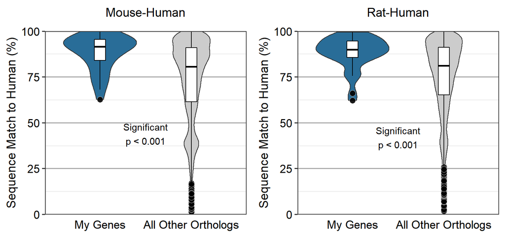

```r
mouse_perc_plot <- new_mouse_ortho %>%
  ggplot(aes(x = Gene_Group, y = MouseToHuman_PercMatch)) +
  geom_violin(aes(fill = Gene_Group), width = 0.8) +
  geom_boxplot(fill = "white", color = "black", width = 0.12,
               outlier.size = 3, outlier.shape = 21, outlier.color = "grey80",
               outlier.fill = "black", outlier.alpha = 0.9) +
  labs(x = "", y = "Sequence Match to Human (%)", title = "Mouse-Human\n") +
  scale_y_continuous(limits = c(0, 100), expand = c(0, 0)) +
  scale_fill_manual(values = c("#296D98", "grey80")) +
  theme(legend.position = "none", axis.ticks.x = element_blank(),
        panel.grid.major.x = element_blank(),
        panel.grid.major.y = element_line(color = "grey65"),
        panel.grid.minor.y = element_line(color = "grey85"),
        axis.text = element_text(size = 13),
        axis.title = element_text(size = 14))

if (stat_mouse_perc$p < 0.001){
  mouse_perc_plot <- mouse_perc_plot +
    annotate(geom = "text", x = 1.5, y = 44,
             label = paste0("Significant\n", "p < 0.001"))
} else if (stat_mouse_perc$p < 0.05){
  mouse_perc_plot <- mouse_perc_plot +
    annotate(geom = "text", x = 1.5, y = 44,
             label = paste0("Significant\n", "p = ", stat_mouse_perc$p))
} else {
  mouse_perc_plot <- mouse_perc_plot +
    annotate(geom = "text", x = 1.5, y = 44,
             label = paste0("Not Significant\n", "p = ", stat_mouse_perc$p))
}

# Rat-Human
rat_perc_plot <- new_rat_ortho %>%
  ggplot(aes(x = Gene_Group, y = RatToHuman_PercMatch)) +
  geom_violin(aes(fill = Gene_Group), width = 0.8) +
  geom_boxplot(fill = "white", color = "black", width = 0.12,
               outlier.size = 3, outlier.shape = 21, outlier.color = "grey80",
               outlier.fill = "black", outlier.alpha = 0.9) +
  labs(x = "", y = "Sequence Match to Human (%)", title = "Rat-Human\n") +
  scale_y_continuous(limits = c(0, 100), expand = c(0, 0)) +
  scale_fill_manual(values = c("#296D98", "grey80")) +
  theme(legend.position = "none", axis.ticks.x = element_blank(),
        panel.grid.major.x = element_blank(),
        panel.grid.major.y = element_line(color = "grey65"),
        panel.grid.minor.y = element_line(color = "grey85"),
        axis.text = element_text(size = 13),
        axis.title = element_text(size = 14))

if (stat_rat_perc$p < 0.001){
  rat_perc_plot <- rat_perc_plot +
    annotate(geom = "text", x = 1.5, y = 42,
             label = paste0("Significant\n", "p < 0.001"))
} else if (stat_rat_perc$p < 0.05){
  rat_perc_plot <- rat_perc_plot +
    annotate(geom = "text", x = 1.5, y = 42,
             label = paste0("Significant\n", "p = ", stat_rat_perc$p))
} else {
  rat_perc_plot <- rat_perc_plot +
    annotate(geom = "text", x = 1.5, y = 42,
             label = paste0("Not Significant\n", "p = ", stat_rat_perc$p))
}

perc_plot <- ggarrange(mouse_perc_plot, rat_perc_plot)
perc_plot
```

### Check Outliers

In our example, there are a few outliers (1 for mouse and 2 for rat). Let’s look at the orthologs with the lowest sequence similarity among our genes.

Mouse:

```r
lowest_sim_mouse <- full_new_ortho %>%
  filter(Gene_Group == "My Genes") %>%
  arrange(MouseToHuman_PercMatch) %>%
  select(BM_Human_Gene_Name, Mouse_ID, MouseToHuman_PercMatch) %>%
  head()
lowest_sim_mouse
```

```
##   BM_Human_Gene_Name           Mouse_ID MouseToHuman_PercMatch
## 1              BCAS1 ENSMUSG00000013523                62.6391
## 2                B2M ENSMUSG00000060802                68.0672
## 3                MBP ENSMUSG00000041607                71.0526
## 4               AMZ1 ENSMUSG00000050022                73.6948
## 5               MOBP ENSMUSG00000032517                75.9563
## 6              FABP7 ENSMUSG00000019874                77.2727
```

Rat:

```r
lowest_sim_rat <- full_new_ortho %>%
  filter(Gene_Group == "My Genes") %>%
  arrange(RatToHuman_PercMatch) %>%
  select(BM_Human_Gene_Name, Rat_ID, RatToHuman_PercMatch) %>%
  head()
lowest_sim_rat
```

```
##   BM_Human_Gene_Name             Rat_ID RatToHuman_PercMatch
## 1                B2M ENSRNOG00000017123              62.1849
## 2              BCAS1 ENSRNOG00000012906              66.1367
## 3               AMZ1 ENSRNOG00000024264              75.5020
## 4               MOBP ENSRNOG00000018700              76.5027
## 5                NTS ENSRNOG00000004179              77.0588
## 6            CCDC88C ENSRNOG00000004482              84.0237
```

In our example, B2M and BCAS1 has low sequence similarity both for both our original mouse gene and its rat ortholog compared to the human orthologs. For mouse, BCAS1 is the low outlier and for rat, both B2M and BCAS1 are the low outliers.

## dN/dS

Next we will compare dN/dS values for the orthologs of our genes.

```r
old_ortho <- getBM(attributes = c("external_gene_name", # Gene symbol
                                  "ensembl_gene_id", # Human ENSEMBL
                                  "mmusculus_homolog_ensembl_gene", # Mouse ID
                                  "rnorvegicus_homolog_ensembl_gene", # Rat ID
                                  # Mouse homology
                                  "mmusculus_homolog_dn",
                                  "mmusculus_homolog_ds",
                                  "mmusculus_homolog_subtype",
                                  "mmusculus_homolog_orthology_type",
                                  "mmusculus_homolog_perc_id",
                                  "mmusculus_homolog_perc_id_r1",
                                  "mmusculus_homolog_orthology_confidence",
                                  # Rat homology
                                  "rnorvegicus_homolog_dn",
                                  "rnorvegicus_homolog_ds",
                                  "rnorvegicus_homolog_subtype",
                                  "rnorvegicus_homolog_orthology_type",
                                  "rnorvegicus_homolog_perc_id",
                                  "rnorvegicus_homolog_perc_id_r1",
                                  "rnorvegicus_homolog_orthology_confidence"),
                   mart = hs_ens99) %>%
  rename(BM_Human_Gene_Name = external_gene_name,
         Human_ID = ensembl_gene_id,
         Mouse_ID = mmusculus_homolog_ensembl_gene,
         Rat_ID = rnorvegicus_homolog_ensembl_gene,
         Mouse_DN = mmusculus_homolog_dn,
         Mouse_DS = mmusculus_homolog_ds,
         Mouse_Ortho_Subtype = mmusculus_homolog_subtype,
         Mouse_Ortho_Type = mmusculus_homolog_orthology_type,
         MouseToHuman_PercMatch = mmusculus_homolog_perc_id,
         HumanToMouse_PercMatch = mmusculus_homolog_perc_id_r1,
         Mouse_Ortho_Conf = mmusculus_homolog_orthology_confidence,
         Rat_DN = rnorvegicus_homolog_dn,
         Rat_DS = rnorvegicus_homolog_ds,
         Rat_Ortho_Subtype = rnorvegicus_homolog_subtype,
         Rat_Ortho_Type = rnorvegicus_homolog_orthology_type,
         RatToHuman_PercMatch = rnorvegicus_homolog_perc_id,
         HumanToRat_PercMatch = rnorvegicus_homolog_perc_id_r1,
         Rat_Ortho_Conf= rnorvegicus_homolog_orthology_confidence) %>%
  mutate(Mouse_DNDS = Mouse_DN/Mouse_DS,
         Rat_DNDS = Rat_DN/Rat_DS) %>%
  mutate(across(everything(), function(x) na_if(x, "NaN")))

# Separate by mouse and rat
old_mouse_ortho <- old_ortho %>%
  select(-contains("Rat")) %>%
  unique() %>%
  mutate(Gene_Group = fct_relevel(ifelse(
    Human_ID %in% human_ids & Mouse_ID %in% mouse_ids,
    "My Genes", "All Other Orthologs"),
    levels = c("My Genes", "All Other Orthologs")))

old_rat_ortho <- old_ortho %>%
  select(-contains("Mouse")) %>%
  unique() %>%
  mutate(Gene_Group = fct_relevel(ifelse(
    Human_ID %in% human_ids & Rat_ID %in% rat_ids,
    "My Genes", "All Other Orthologs"),
    levels = c("My Genes", "All Other Orthologs")))

# Join dataframes for reference later
full_old_ortho <- Reduce(function(x, y)
  full_join(x, y), list(old_mouse_ortho, old_rat_ortho)) %>%
  relocate(Gene_Group, .before = everything()) %>%
  unique() %>%
  select(-Mouse_Ortho_Subtype, -Rat_Ortho_Subtype)
```

### Statistics

Getting statistics for dN/dS as before with sequence similarity:

```r
# Stats comparing each dataset to the ones in no datasets
stat_mouse_dnds <- old_mouse_ortho %>%
  filter(!is.na(Mouse_DNDS), Mouse_DNDS != Inf,
         Mouse_Ortho_Type == "ortholog_one2one") %>%
  wilcox_test(Mouse_DNDS ~ Gene_Group) %>%
  filter(group2 == "All Other Orthologs") %>%
  rename(Comparison = ".y.")
stat_rat_dnds <- old_rat_ortho %>%
  filter(!is.na(Rat_DNDS), Rat_DNDS != Inf,
         Rat_Ortho_Type == "ortholog_one2one") %>%
  wilcox_test(Rat_DNDS ~ Gene_Group) %>%
  filter(group2 == "All Other Orthologs") %>%
  rename(Comparison = ".y.")

# Medians
mouse_dnds_medians <- old_mouse_ortho %>%
  filter(!is.na(Mouse_DNDS), Mouse_DNDS != Inf) %>%
  group_by(Gene_Group) %>%
  summarize(DNDS_withMouse_Median = median(Mouse_DNDS))
rat_dnds_medians <- old_rat_ortho %>%
  filter(!is.na(Rat_DNDS), Rat_DNDS != Inf) %>%
  group_by(Gene_Group) %>%
  summarize(DNDS_withRat_Median = median(Rat_DNDS))

# View stats and medians
stat_dnds <- full_join(stat_mouse_dnds, stat_rat_dnds)
medians_dnds <- full_join(mouse_dnds_medians, rat_dnds_medians)
```

Statistics:

```r
stat_dnds
```

```
## # A tibble: 2 x 7
##   Comparison group1   group2                 n1    n2 statistic     p
##   <chr>      <chr>    <chr>               <int> <int>     <dbl> <dbl>
## 1 Mouse_DNDS My Genes All Other Orthologs    27 15068    182477 0.355
## 2 Rat_DNDS   My Genes All Other Orthologs    28 14260    168118 0.148
```

Medians:

```r
medians_dnds
```

```
## # A tibble: 2 x 3
##   Gene_Group          DNDS_withMouse_Median DNDS_withRat_Median
##   <fct>                               <dbl>               <dbl>
## 1 My Genes                           0.0889              0.0763
## 2 All Other Orthologs                0.156               0.139
```

For this example, there is no statistically significant difference between the dN/dS values for either our original mouse genes or their rat orthologs compared to human orthologs.

Note that this analysis has been simplified so that it analyzes all genes with orthologs according to the January 2020 ENSEMBL database (the analysis from the manuscript excludes orthologs that are not present in both the January 2020 and April 2022 versions). As genomes are updated and new information becomes available, genes that were once thought to be orthologs with one another may be revised and vice versa. You may want to check your genes to verify that the orthologs in the 2020 and 2022 ENSEMBL versions are the same.

### Plot

Next, create a plot.

*The y axes on these plots have been modified to cap at 3 for clarity. To change this, remove the `scale_y_continuous()` function from the plots.*

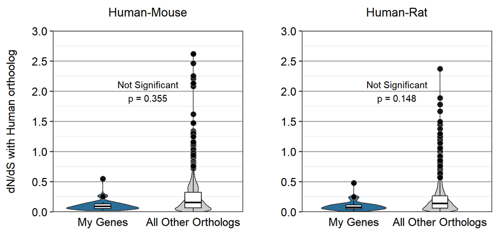

```r
mouse_dnds_plot <- old_mouse_ortho %>%
  ggplot(aes(x = Gene_Group, y = Mouse_DNDS)) +
  geom_violin(aes(fill = Gene_Group), width = 0.8) +
  geom_boxplot(fill = "white", color = "black", width = 0.18,
               outlier.size = 3, outlier.shape = 21, outlier.color = "grey80",
               outlier.fill = "black", outlier.alpha = 0.9) +
  labs(x = "", y = "dN/dS with Human orthoolog\n",
       title = "Human-Mouse\n") +
  scale_x_discrete(expand = c(0, 0.55)) +
  scale_y_continuous(limits = c(0, 3), breaks = seq(0, 3, 0.5), expand = c(0, 0)) +
  scale_fill_manual(values = c("#296D98", "grey80")) +
  theme(legend.position = "none", axis.ticks.x = element_blank(),
        panel.grid.major.x = element_blank(),
        panel.grid.major.y = element_line(color = "grey65"),
        panel.grid.minor.y = element_line(color = "grey85"),
        axis.text = element_text(size = 13),
        axis.title.x = element_text(size = 14),
        axis.title.y = element_text(size = 13))

if (stat_mouse_dnds$p < 0.001){
  mouse_dnds_plot <- mouse_dnds_plot +
    annotate(geom = "text", x = 1.5, y = 2,
             label = paste0("Significant\n", "p < 0.001"))
} else if (stat_mouse_dnds$p < 0.05){
  mouse_dnds_plot <- mouse_dnds_plot +
    annotate(geom = "text", x = 1.5, y = 2,
             label = paste0("Significant\n", "p = ", stat_mouse_dnds$p))
} else {
  mouse_dnds_plot <- mouse_dnds_plot +
    annotate(geom = "text", x = 1.5, y = 2,
             label = paste0("Not Significant\n", "p = ", stat_mouse_dnds$p))
}

rat_dnds_plot <- old_rat_ortho %>%
  ggplot(aes(x = Gene_Group, y = Rat_DNDS)) +
  geom_violin(aes(fill = Gene_Group), width = 0.75) +
  geom_boxplot(fill = "white", color = "black", width = 0.18,
               outlier.size = 3, outlier.shape = 21, outlier.color = "grey80",
               outlier.fill = "black", outlier.alpha = 0.9) +
  labs(x = "", y = "dN/dS with Human orthoolog\n",
       title = "Human-Rat\n") +
  scale_y_continuous(limits = c(0, 3), breaks = seq(0, 3, 0.5), expand = c(0, 0)) +
  scale_fill_manual(values = c("#296D98", "grey80")) +
  theme(legend.position = "none", axis.ticks.x = element_blank(),
        panel.grid.major.x = element_blank(),
        panel.grid.major.y = element_line(color = "grey65"),
        panel.grid.minor.y = element_line(color = "grey85"),
        axis.text = element_text(size = 13),
        axis.title.x = element_text(size = 14),
        axis.title.y = element_text(size = 13, color = "white"))

if (stat_rat_dnds$p < 0.001){
  rat_dnds_plot <- rat_dnds_plot +
    annotate(geom = "text", x = 1.5, y = 2,
             label = paste0("Significant\n", "p < 0.001"))
} else if (stat_rat_dnds$p < 0.05){
  rat_dnds_plot <- rat_dnds_plot +
    annotate(geom = "text", x = 1.5, y = 2,
             label = paste0("Significant\n", "p = ", stat_rat_dnds$p))
} else {
  rat_dnds_plot <- rat_dnds_plot +
    annotate(geom = "text", x = 1.5, y = 2,
             label = paste0("Not Significant\n", "p = ", stat_rat_dnds$p))
}

# Save plots
dnds_plot <- ggarrange(mouse_dnds_plot, rat_dnds_plot)
dnds_plot
```

## Gene Expression Patterns Across Development

For the conservation analysis, our final goal is to compare orthologs’ patterns of expression across development in the forebrain of mouse, rat, and human. This data comes from Cardoso-Moreira et al. (2020), “Developmental gene expression differences between humans and mammalian models” published in Cell Reports.

The data from their paper uses human genes and compares to mouse, rat, and other species. To do this analysis, we have to search their data using the humnan orthologs of our genes rather than searching for the exact name of our mouse or rat genes.

This code can be easily modified to examine the cerebellum instead of the forebrain by downloading the table for cerebellum instead.

```r
# "Developmental gene expression differences between humans & mammalian models"
# Cardoso-Moriera et al. (2020)
# Table S3A. Comparison of brain temporal trajectories

# Includes human, mouse, rat, rabbit, rhesus
cons_orig <- read_excel(cm_file, sheet = 1, skip = 2)

# Tidy and create new columns
# Note that with the new column "Conservation" we DO NOT have enough information
# to determine whether a gene's temporal developmental expression is shared
# between mouse and rat.
cons2020 <- cons_orig %>%
  select(-c(starts_with("Prob"), Rabbit, Rhesus)) %>%
  # Categorize by conservation (see above note)
  mutate(Conservation = fct_relevel(case_when(
    (Mouse == "Same" & Rat == "Same") ~ "HMR",
    (Mouse == "Same" & Rat == "Different") ~ "HM",
    (Mouse == "Different" & Rat == "Same") ~ "HR",
    (Mouse == "Different" & Rat == "Different") ~ "H",
    TRUE ~ NA_character_),
    c("HMR", "HM", "HR", "H"))) %>%
  mutate(across(everything(), function(x) na_if(x, "NA")))

cons2020_with_incompletes <- cons_orig %>%
  select(-c(starts_with("Prob"), Rabbit, Rhesus)) %>%
  # Categorize by conservation (see above note)
  mutate(Conservation = fct_relevel(case_when(
    (Mouse == "Same" & Rat == "Same") ~ "HMR",
    (Mouse == "Same" & Rat == "Different") ~ "HM",
    (Mouse == "Different" & Rat == "Same") ~ "HR",
    (Mouse == "Different" & Rat == "Different") ~ "H",
    # NA genes were not tested because they didn't have complete data.
    (Mouse == "Same" & Rat == "NA") ~ "HM*",
    (Mouse == "Different" & Rat == "NA") ~ "H*",
    (Mouse == "NA" & Rat == "Same") ~ "HR*",
    (Mouse == "NA" & Rat == "Different") ~ "H*",
    TRUE ~ NA_character_),
    c("HMR", "HM", "HR", "H", "HM*", "HR*", "H*"))) %>%
  mutate(across(everything(), function(x) na_if(x, "NA")))

if (rodent_species == "mouse"){
  cons2020 <- cons2020 %>%
    mutate(Gene_Group = fct_relevel(ifelse(
      Human_ID %in% human_ids, "My Genes", "All Other Orthologs"),
      levels = c("My Genes", "All Other Orthologs")))

  cons2020_with_incompletes <- cons2020_with_incompletes %>%
    mutate(Gene_Group = fct_relevel(ifelse(
      Human_ID %in% human_ids, "My Genes", "All Other Orthologs"),
      levels = c("My Genes", "All Other Orthologs")))

} else if (rodent_species == "rat"){
  cons2020 <- cons2020 %>%
    mutate(Gene_Group = fct_relevel(ifelse(
      Human_ID %in% human_ids, "My Genes", "All Other Orthologs"),
      levels = c("My Genes", "All Other Orthologs")))

  cons2020_with_incompletes <- cons2020_with_incompletes %>%
    mutate(Gene_Group = fct_relevel(ifelse(
      Human_ID %in% human_ids, "My Genes", "All Other Orthologs"),
      levels = c("My Genes", "All Other Orthologs")))

} else {
  print("Error")
}
```

In all likelihood, not all of our genes of interest are present in the dataset. This is because the original authors looked at genes that were one-to-one orthologs in mouse, rat, etc. Let’s check how many of our genes are in this dataset:

```r
# How many genes are in each Gene_Group in the cons2020 dataset?
cons2020 %>%
  group_by(Gene_Group) %>%
  count()
```

```
## # A tibble: 2 x 2
## # Groups:   Gene_Group [2]
##   Gene_Group              n
##   <fct>               <int>
## 1 My Genes               25
## 2 All Other Orthologs  9825
```

```r
human_ids[human_ids %in% (cons2020 %>%
                            filter(Gene_Group == "My Genes") %>%
                            pull(Human_ID))]
```

```
##  [1] "ENSG00000132702" "ENSG00000064787" "ENSG00000116161" "ENSG00000164434"
##  [5] "ENSG00000133636" "ENSG00000139289" "ENSG00000015133" "ENSG00000164326"
##  [9] "ENSG00000100271" "ENSG00000167588" "ENSG00000071242" "ENSG00000164736"
## [13] "ENSG00000143248" "ENSG00000026025" "ENSG00000006530" "ENSG00000168314"
## [17] "ENSG00000164116" "ENSG00000133639" "ENSG00000122877" "ENSG00000185950"
## [21] "ENSG00000091622" "ENSG00000197971" "ENSG00000174945" "ENSG00000166710"
## [25] "ENSG00000155980"
```

### Statistics

Now we will do a Fisher’s Exact Test to see if our genes are more (or less!) conserved overall in their developmental patterns of expression in the forebrain of mouse, rat, and human:

```r
# Fisher's Exact Test
fisher_table <- table(cons2020$Gene_Group, cons2020$Conservation)
fisher_test <- fisher.test(fisher_table, simulate.p.value = FALSE)
```

Input data (number of genes in each group):

```r
fisher_table
```

```
##
##                        HMR   HM   HR    H
##   My Genes              18    0    2    1
##   All Other Orthologs 5529  265  369  627
```

Statistical results:

```r
fisher_test
```

```
##
##  Fisher's Exact Test for Count Data
##
## data:  fisher_table
## p-value = 0.6427
## alternative hypothesis: two.sided
```

There is no statistically significant difference in conservation of developmental gene expression for our example genes.

### Plot

We can again make a plot of our data:

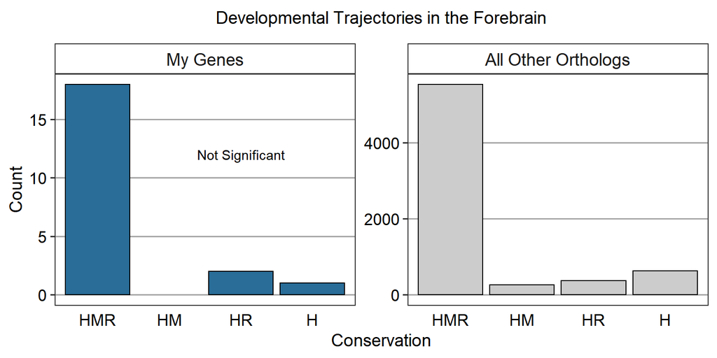

```r
cm_plot <- cons2020 %>%
  filter(!is.na(Conservation)) %>%
  ggplot(aes(x = Conservation, fill = Gene_Group)) +
  geom_bar(aes(group = 1), show.legend = FALSE,
           position = position_dodge2(preserve = "single"),
           color = "black") +
  scale_fill_manual(values = c("#296D98", "grey80")) +
  labs(y = "Count",
       title = "Developmental Trajectories in the Forebrain\n") +
  theme(axis.ticks.x = element_blank(), panel.grid.major.x = element_blank(),
        panel.grid.major.y = element_line(color = "grey65"),
        panel.grid.minor.y = element_blank(),
        axis.text = element_text(size = 13),
        axis.title = element_text(size = 14),
        strip.text.x = element_text(size = 14),
        strip.background = element_rect(fill = "white")) +
  facet_wrap(~ Gene_Group, scales = "free_y", nrow = 1)

if (fisher_test$p.value < 0.001){
  sig_text <- data.frame(Conservation = c(3, NA), count = c(12, NA),
                         lab = c(paste0("Significant\n", "p < 0.001"), ""),
                         Gene_Group = factor("My Genes",
                                             levels = c("My Genes",
                                                        "All Other Orthologs")))
  cm_plot <- cm_plot + geom_text(data = sig_text,
                                 aes(x = Conservation, y = count, label = lab))
} else if (fisher_test$p.value < 0.05){
  sig_text <- data.frame(Conservation = c(3, NA), count = c(12, NA),
                         lab = c(paste0("Significant\n", "p = ",
                                        fisher_test$p.value), ""),
                         Gene_Group = factor("My Genes",
                                             levels = c("My Genes",
                                                        "All Other Orthologs")))
  cm_plot <- cm_plot + geom_text(data = sig_text,
                                 aes(x = Conservation, y = count, label = lab))
} else {
  sig_text <- data.frame(Conservation = c(3, NA), count = c(12, NA),
                         lab = c("Not Significant", ""),
                         Gene_Group = factor("My Genes",
                                             levels = c("My Genes",
                                                        "All Other Orthologs")))
  cm_plot <- cm_plot + geom_text(data = sig_text,
                      aes(x = Conservation, y = count, label = lab))
}

cm_plot
```

Although this is not signficantly different from all other orthologs, we can see that our example genes that were present in this dataset are, for the most part, conserved in their developmental expression patterns between human and mouse, and human and rat. Note that this analysis does not look at mouse vs. rat directly, as that information was not present in the original dataset.

### Check Outliers

Which of our genes are not conserved between human and mouse, and human and rat (i.e. not HMR)?

```r
cons2020 %>%
  filter(Gene_Group == "My Genes", Conservation != "HMR") %>%
  select(-Gene_Group)
```

```
## # A tibble: 3 x 5
##   Human_ID        Gene_symbol Mouse     Rat       Conservation
##   <chr>           <chr>       <chr>     <chr>     <fct>
## 1 ENSG00000116161 CACYBP      Different Different H
## 2 ENSG00000133636 NTS         Different Same      HR
## 3 ENSG00000143248 RGS5        Different Same      HR
```

## Create and Save Final CSV

Lastly, we will create the final dataframe with all of this information and save it as a CSV file.

```r
# Get dataframes wit just candidate genes
full_old_ortho_candidates <- full_old_ortho %>% filter(Gene_Group == "My Genes")
full_new_ortho_candidates <- full_new_ortho %>% filter(Gene_Group == "My Genes")

# For some genes, the RAT orthologs changed between the new and old Ensembl
# versions. The mouse orthologs are all the same (Any_Mouse_Same == TRUE for all
# genes). Have separate columns for new and old rat orthologs.
full_all_cons_df <- full_old_ortho_candidates %>%
  select(-contains(c("Perc", "Ortho_Conf")), -BM_Human_Gene_Name) %>%
  rename(Ensembl_99_Mouse_Ortho_Type = Mouse_Ortho_Type,
         Ensembl_99_Rat_Ortho_Type = Rat_Ortho_Type,
         Ensembl_99_Rat_ID = Rat_ID,
         Ensembl_99_Mouse_ID = Mouse_ID) %>%
  mutate(across(everything(), function(x) na_if(x, ""))) %>%
  full_join(full_new_ortho_candidates) %>%
  rename(Ensembl_106_Mouse_Ortho_Type = Mouse_Ortho_Type,
         Ensembl_106_Rat_Ortho_Type = Rat_Ortho_Type,
         Ensembl_106_Rat_ID = Rat_ID,
         Ensembl_106_Mouse_ID = Mouse_ID) %>%
  select(-contains("Ortho_Conf")) %>%
  select(-c(Mouse_DN, Mouse_DS, Rat_DN, Rat_DS)) %>%
  relocate(Ensembl_99_Rat_Ortho_Type, .after = Mouse_DNDS) %>%
  relocate(BM_Human_Gene_Name, .after = Gene_Group) %>%
  mutate(Mouse_Same_ID = ifelse(Ensembl_99_Mouse_ID == Ensembl_106_Mouse_ID,
                              TRUE, FALSE),
         Rat_Same_ID = ifelse(Ensembl_99_Rat_ID == Ensembl_106_Rat_ID,
                              TRUE, FALSE),
         Mouse_Same_Ortho = case_when(Ensembl_99_Mouse_Ortho_Type ==
                                        Ensembl_106_Mouse_Ortho_Type ~ TRUE,
                                      Ensembl_99_Mouse_Ortho_Type !=
                                        Ensembl_106_Mouse_Ortho_Type |
                                        is.na(Ensembl_99_Mouse_Ortho_Type) |
                                        is.na(Ensembl_106_Mouse_Ortho_Type)
                                      ~ FALSE),
         Rat_Same_Ortho = case_when(Ensembl_99_Rat_Ortho_Type ==
                                      Ensembl_106_Rat_Ortho_Type ~ TRUE,
                                    Ensembl_99_Rat_Ortho_Type !=
                                      Ensembl_106_Rat_Ortho_Type |
                                      is.na(Ensembl_99_Rat_Ortho_Type) |
                                      is.na(Ensembl_106_Rat_Ortho_Type)
                                    ~ FALSE)) %>%
  group_by(Human_ID) %>%
  mutate(Any_Mouse_Same = ifelse(sum(Mouse_Same_ID) >= 1, TRUE, FALSE),
         Any_Rat_Same = ifelse(sum(Rat_Same_ID) >= 1, TRUE, FALSE),
         Any_Mouse_Ortho_Same = ifelse(sum(Mouse_Same_Ortho) >= 1, TRUE, FALSE),
         Any_Rat_Ortho_Same = ifelse(sum(Rat_Same_Ortho) >= 1, TRUE, FALSE),
         Ensembl_99_Mouse_ID = "Same ID as Ensembl release 106",
         Ensembl_99_Rat_ID = case_when(Rat_Same_ID == 1 ~ "Same ID as Ensembl release 106",
                                       Any_Rat_Same == TRUE ~ Ensembl_106_Rat_ID,
                                       TRUE ~ NA_character_)) %>%
  ungroup() %>%
  filter(Rat_Same_ID == TRUE | (Rat_Same_ID == FALSE & Any_Rat_Same == FALSE) |
           is.na(Any_Rat_Same)) %>%
  mutate(across(everything(), function(x)
    gsub("ortholog_one2one", "One-to-one ortholog", x))) %>%
  mutate(across(everything(), function(x)
    gsub("ortholog_many2many", "Many-to-many orthologs", x))) %>%
  mutate(across(contains("Mouse_Ortho_Type"), function(x)
    gsub("ortholog_one2many", "Many mouse to one human ortholog", x))) %>%
  mutate(across(contains("Rat_Ortho_Type"), function(x)
    gsub("ortholog_one2many", "Many rat to one human ortholog", x))) %>%
  mutate(across(everything(), function(x) na_if(x, ""))) %>%
  left_join(cons2020_with_incompletes) %>%
  droplevels() %>%
  select(c(Gene_Group, BM_Human_Gene_Name, Human_ID, Conservation,
           Ensembl_106_Mouse_ID, Ensembl_106_Mouse_Ortho_Type,
           MouseToHuman_PercMatch, HumanToMouse_PercMatch, Ensembl_99_Mouse_ID,
           Ensembl_99_Mouse_Ortho_Type, Mouse_DNDS, Any_Mouse_Same,
           Ensembl_106_Rat_ID, Ensembl_106_Rat_Ortho_Type, RatToHuman_PercMatch,
           HumanToRat_PercMatch, Ensembl_99_Rat_ID, Ensembl_99_Rat_Ortho_Type,
           Rat_DNDS, Any_Rat_Same))

# Write to CSV file
write.csv(full_all_cons_df, cons_csv_file)
```